# PA1_file.Rmd

wandyb

17 Jun 2016

# Reproducible Research: Peer Assessment 1

### Loading and preprocessing the data

Load the libraries first

```r
library(plyr)
library(ggplot2)
```

Now load the data

```r
data <- read.csv("./activity.csv")
```

## What is mean total number of steps taken per day?

Calculate the number of steps per day using the ddply function

```r
stepsperday <- ddply (data, .(date), summarize, stepSum = sum (steps, na.rm = TRUE))
```

### 1. Make a histogram of the total number of steps taken each day

Plot the data in a histogramm

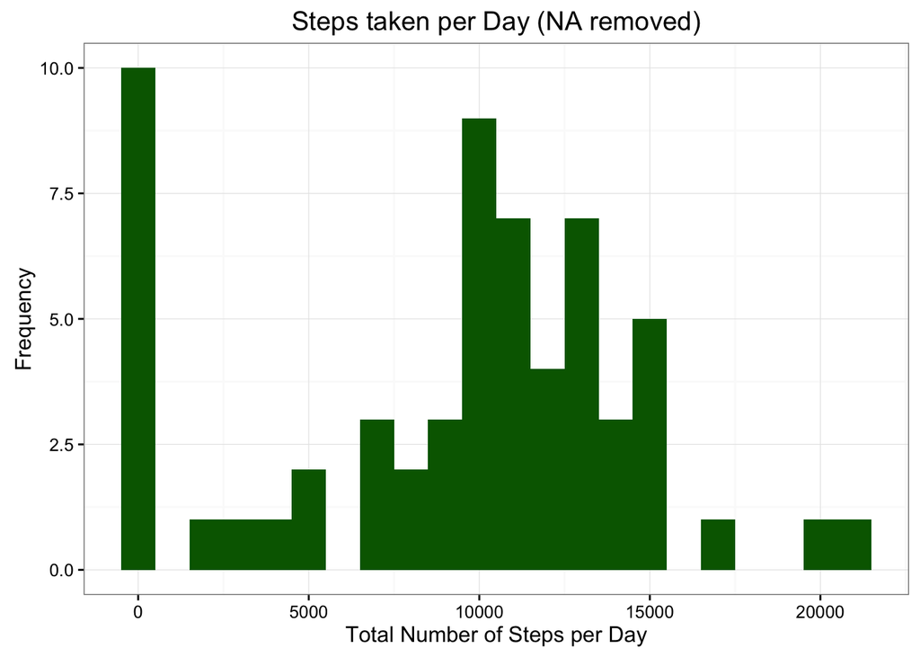

```r
hist <- ggplot(stepsperday, aes(x = stepSum)) +
        geom_histogram(fill = "darkgreen", binwidth = 1000) +
        theme_bw() +
        labs(title = "Steps taken per Day (NA removed)",
             x = "Total Number of Steps per Day", y = "Frequency")
plot(hist)
```

### 2. Calculate and report the mean and median total number of steps taken per day

Using the summary function

```r
summary(stepsperday)
```

```
##          date       stepSum
##  2012-10-01: 1   Min.   :    0
##  2012-10-02: 1   1st Qu.: 6778
##  2012-10-03: 1   Median :10395
##  2012-10-04: 1   Mean   : 9354
##  2012-10-05: 1   3rd Qu.:12811
##  2012-10-06: 1   Max.   :21194
##  (Other)   :55
```

Or just calculating the mean…

```r
means <- mean(stepsperday$stepSum)
means
```

```
## [1] 9354.23
```

… and the median, respectively.

```r
medians <- median(stepsperday$stepSum)
medians
```

```
## [1] 10395
```

The **mean** of the data is 9354.2295082 and the **median** is 10395.

## What is the average daily activity pattern?

### 1. Make a time series plot of the 5-minute interval (x-axis) and the average number of steps taken, averaged across all days (y-axis)

Calculate average first

```r
average <- aggregate(steps ~ interval, data = data, FUN = mean, na.rm = TRUE)
```

Then plot the data

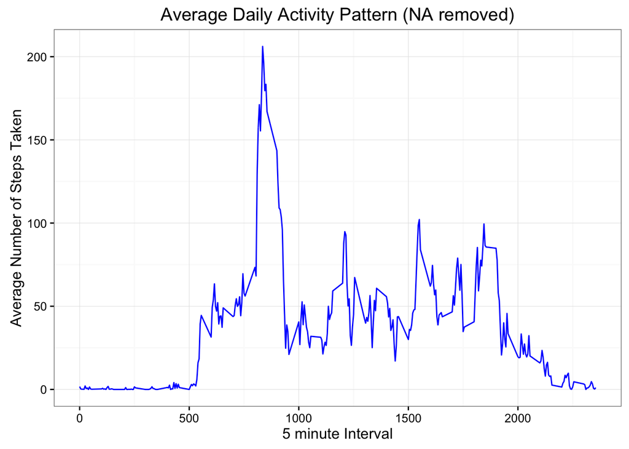

```r
pattern <- ggplot(data = average, aes(x = interval, y = steps)) +
           geom_line(color = "blue") +
           theme_bw() +
           labs(title = "Average Daily Activity Pattern (NA removed)",
                x = "5 minute Interval", y = "Average Number of Steps Taken")
plot(pattern)
```

## 2. Which 5-minute interval, on average across all the days in the dataset, contains the maximum number of steps?

```r
most <- average$interval[which.max(average$steps)]
most
```

```
## [1] 835
```

The the intervall that contains the most number of steps taken per day is 835.

## Imputing missing values

### 1. Calculate and report the total number of missing values in the dataset (i.e. the total number of rows with NAs)

Calculate the number of missing values first

```r
sumNA <- sum(is.na(data$steps))
sumNA
```

```
## [1] 2304
```

### 2. Create a new dataset that is equal to the original dataset but with the missing data filled

Make new “clean” dataset

```r
cleanData <- data
cleanData$steps[is.na(cleanData$steps)] <- tapply(cleanData$steps, cleanData$interval, mean, na.rm = TRUE)
```

### 3. Make a histogram of the total number of steps taken each day and Calculate and report the mean and median total number of steps taken per day.

Plot the data

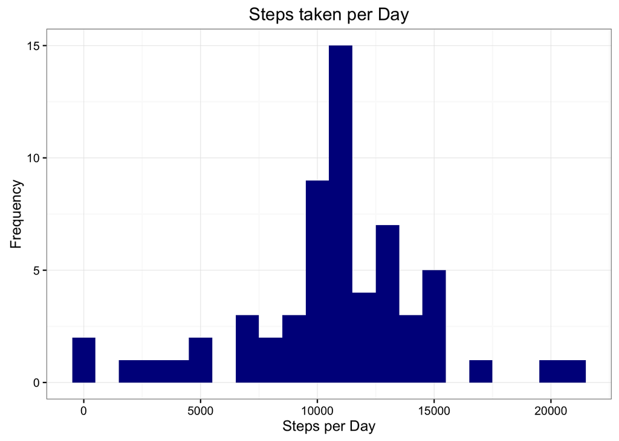

```r
averageNA <- aggregate(steps ~ date, data = cleanData, FUN = sum)
histNA <- ggplot(averageNA, aes(x = steps)) +
          geom_histogram(fill = "darkblue", binwidth = 1000) +
          theme_bw() +
          labs(title = "Steps taken per Day", x = "Steps per Day", y = "Frequency")
plot(histNA)
```

Calculate mean

```r
meanNA <- mean(averageNA$steps)
meanNA
```

```
## [1] 10766.19
```

and median

```r
medianNA <- median(averageNA$steps)
medianNA
```

```
## [1] 10766.19
```

The difference is not very big. The mean before removing the NAs was 9354 and removing the NAs shifted the mean to the right to 10766. The median also shifted slightly from 10395 to 10766.

## Are there differences in activity patterns between weekdays and weekends?

Change date to as.POSIXct and add the weekday and weekend identifier, respectively.

```r
dataNew <- data
dataNew$date <- as.POSIXct(data$date)
dataNew$day <- ifelse(weekdays(dataNew$date) == "Saturday" | weekdays(dataNew$date) == "Sunday" ,"weekend","weekday")
```

Make a new dataframe

```r
summaryWeek <- aggregate(steps ~ interval + day, data = dataNew, sum)
```

Plot the data

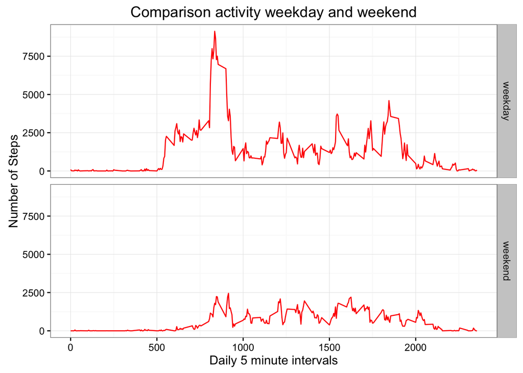

```r
weekly <- ggplot(summaryWeek, aes(x = interval, y = steps)) +
          geom_line(color = "red") +
          theme_bw() +
          labs(title = "Comparison activity weekday and weekend", x = "Daily 5 minute intervals", y ="Number of Steps")
weeklyplot <- weekly + facet_grid(day ~ .)
plot(weeklyplot)
```